# Chapter 2: Regression and model validation

Let’s first read data from the local file into a data frame

```r
learning2014 <- read.table("/Users/lehtint9/IODS-project/data/learning2014.txt")
```

Next let’s have a look a the dimensions and structure of the data set

```r
dim(learning2014)
```

```
## [1] 166   7
```

```r
str(learning2014)
```

```
## 'data.frame':    166 obs. of  7 variables:
##  $ gender  : Factor w/ 2 levels "F","M": 1 2 1 2 2 1 2 1 2 1 ...
##  $ age     : int  53 55 49 53 49 38 50 37 37 42 ...
##  $ attitude: int  37 31 25 35 37 38 35 29 38 21 ...
##  $ deep    : num  3.75 2.88 3.88 3.5 3.75 ...
##  $ stra    : num  3.38 2.75 3.62 3.12 3.62 ...
##  $ surf    : num  2.58 3.17 2.25 2.25 2.83 ...
##  $ points  : int  25 12 24 10 22 21 21 31 24 26 ...
```

The data frame has 166 observations of 7 variables. The variables are gender (female or male), age, four attributes (attitude, deep, stra, surf) and the total points.

To examine the variables, let us print a summary of them. This show overview statistics of all variables.

```r
summary(learning2014)
```

```
##  gender       age           attitude          deep            stra
##  F:110   Min.   :17.00   Min.   :14.00   Min.   :1.625   Min.   :1.250
##  M: 56   1st Qu.:21.00   1st Qu.:26.00   1st Qu.:3.500   1st Qu.:2.625
##          Median :22.00   Median :32.00   Median :3.875   Median :3.188
##          Mean   :25.51   Mean   :31.43   Mean   :3.796   Mean   :3.121
##          3rd Qu.:27.00   3rd Qu.:37.00   3rd Qu.:4.250   3rd Qu.:3.625
##          Max.   :55.00   Max.   :50.00   Max.   :4.875   Max.   :5.000
##       surf           points
##  Min.   :1.583   Min.   : 7.00
##  1st Qu.:2.417   1st Qu.:19.00
##  Median :2.833   Median :23.00
##  Mean   :2.787   Mean   :22.72
##  3rd Qu.:3.167   3rd Qu.:27.75
##  Max.   :4.333   Max.   :33.00
```

We will need the following additional libraries to analyse the data graphically:

```r
library(GGally)
library(ggplot2)
```

To explore the variables graphically and specifically the relationships between them, we will draw an overview plot matrix with ggpairs

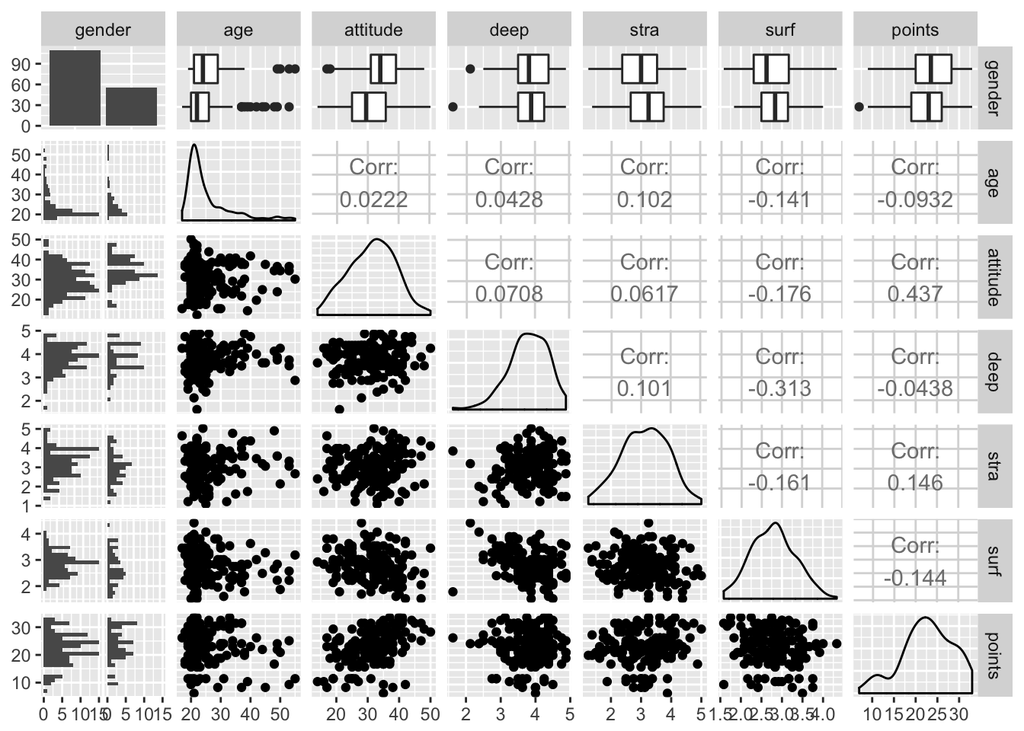

```r
p <- ggpairs(learning2014, mapping = aes(), lower = list(combo = wrap("facethist", bins = 20)))
p
```

The `gender` distribution is clearly skewed, `age` as well (as expected with what I assume are university students). `age` does not significantly correlate with any of the variables.

The three highest linear correlations (in terms of abosulte value) with the `points` variable are in `attitude` (0.437), `stra` (0.146) and `surf` (-0.144), however correlations between `points` and `stra` & `surf` are rather low. `surf` seems to be to some extent correlated with `attitude` (-0.176) and `stra` (-0.161). Correlation between `stra` and `attitude` is low (0.0617).

Based on the observations on correlations, let’s regress `points` on `attitude`, `stra` and `surf` and print out a summary of the model

```r
my_model <- lm(points ~ attitude + stra + surf, data = learning2014)
summary(my_model)
```

```
##
## Call:
## lm(formula = points ~ attitude + stra + surf, data = learning2014)
##
## Residuals:
##      Min       1Q   Median       3Q      Max
## -17.1550  -3.4346   0.5156   3.6401  10.8952
##
## Coefficients:
##             Estimate Std. Error t value Pr(>|t|)
## (Intercept) 11.01711    3.68375   2.991  0.00322 **
## attitude     0.33952    0.05741   5.913 1.93e-08 ***
## stra         0.85313    0.54159   1.575  0.11716
## surf        -0.58607    0.80138  -0.731  0.46563
## ---
## Signif. codes:  0 '***' 0.001 '**' 0.01 '*' 0.05 '.' 0.1 ' ' 1
##
## Residual standard error: 5.296 on 162 degrees of freedom
## Multiple R-squared:  0.2074, Adjusted R-squared:  0.1927
## F-statistic: 14.13 on 3 and 162 DF,  p-value: 3.156e-08
```

The statistically significant coefficients are the `intercept` (at 0.01 level) and `attitude` (at 0.001 level).